# Stats 101 Fall 2021 Midterm

DKU Stats 101 Fall 2021 Session 1

Anonymous

9/7/2021

# Assignment instructions

## Task

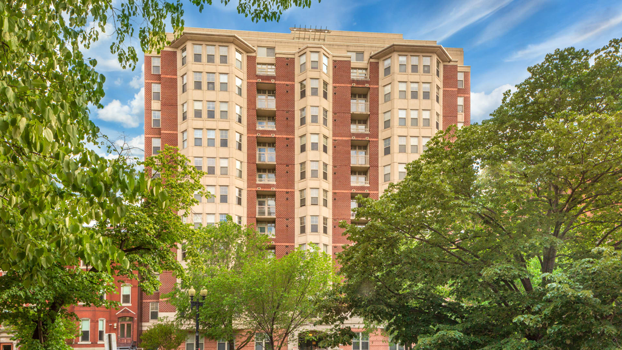

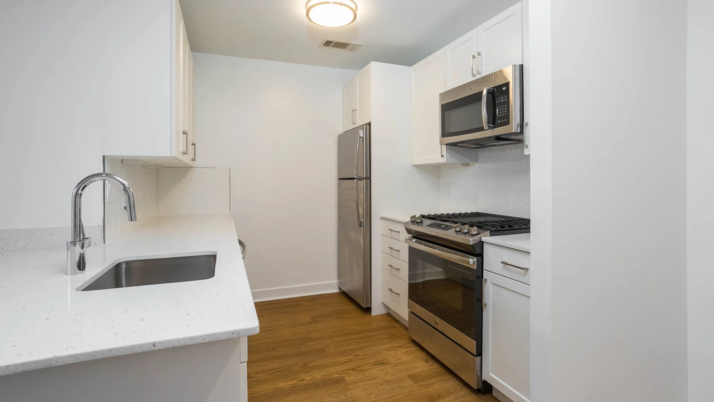

1210 Mass Avenue

One of the most important tasks of any junior intern at a property management company is to develop reports on future investment possibilities. Rental prices can vary a lot depending on the various features of the apartment and on the quality of the building it is in.

Your task is to imagine yourself as an intern at a property investment firm. You are tasked with writing a report to your boss that attempts to determine what are the factors that best predict rental prices. Your team will use this information to help plan future rental property acquisitions.

In particular, you need to find specific factors that are associated rental price and create a high quality regression model with multiple variables that explains this relationship